# SkinCell_Analysis

## Introduction

Skincells dataset has 3 variables, day of observation, amount of time colony was exposed to solar simulator, number of live cells in the colony. Experiment was performed on 4 days, and collected 118 observations.

Sample data can be seen in Table1.

```r
head(data)
```

```
##   day time logcells
## 1   1    0        7
## 2   1    0       10
## 3   1    0       10
## 4   1    0       12
## 5   1    0        9
## 6   1    1        5
```

## Descriptive Analysis

Refer Figure-1 below

[figure not shown]

```r
g   + geom_boxplot(outlier.colour = "green")  + coord_flip()
```

A linear regression model was fitted to these data with logcells as a continuous response variable, time is a continous predictor, day is a categorical predictor. To allow maximum flexibility in the initial model, an interaction of day and time was included.

## Model - 1

```r
data$day <- as.factor(data$day)
reg.model<-lm(logcells~(time+day+day*time),data=data)
summary(reg.model)
```

```
##
## Call:
## lm(formula = logcells ~ (time + day + day * time), data = data)
##
## Residuals:
##     Min      1Q  Median      3Q     Max
## -4.7879 -1.7144 -0.4493  1.4934  6.7416
##
## Coefficients:
##             Estimate Std. Error t value Pr(>|t|)
## (Intercept)   8.2161     0.8248   9.961  < 2e-16 ***
## time         -1.4282     0.3809  -3.750 0.000284 ***
## day2         -2.2981     1.2268  -1.873 0.063694 .
## day3         -1.6523     1.1851  -1.394 0.166065
## day4         -1.1056     1.1941  -0.926 0.356547
## time:day2     0.4528     0.5558   0.815 0.416983
## time:day3     0.3519     0.5264   0.668 0.505283
## time:day4     0.1198     0.5264   0.228 0.820335
## ---
## Signif. codes:  0 '***' 0.001 '**' 0.01 '*' 0.05 '.' 0.1 ' ' 1
##
## Residual standard error: 2.491 on 110 degrees of freedom
## Multiple R-squared:  0.3059, Adjusted R-squared:  0.2618
## F-statistic: 6.926 on 7 and 110 DF,  p-value: 7.924e-07
```

```r
anova(reg.model)
```

```
## Analysis of Variance Table
##
## Response: logcells
##            Df Sum Sq Mean Sq F value    Pr(>F)
## time        1 263.08 263.080 42.4130 2.285e-09 ***
## day         3  32.26  10.752  1.7334    0.1643
## time:day    3   5.40   1.802  0.2905    0.8322
## Residuals 110 682.31   6.203
## ---
## Signif. codes:  0 '***' 0.001 '**' 0.01 '*' 0.05 '.' 0.1 ' ' 1
```

p-value is statistically significant for time, indicating that cells count is predominantly dependent on exposure time. Every unit of increased exposure time, cells count decreases by 1.4 units Prediction accuracy of the model is 26%, which is very low. Outlier detection analysis is performed to check, if there were incorrect observations captured due to contamination or any other factors.

[output not shown]

[output cut: 226 more lines]

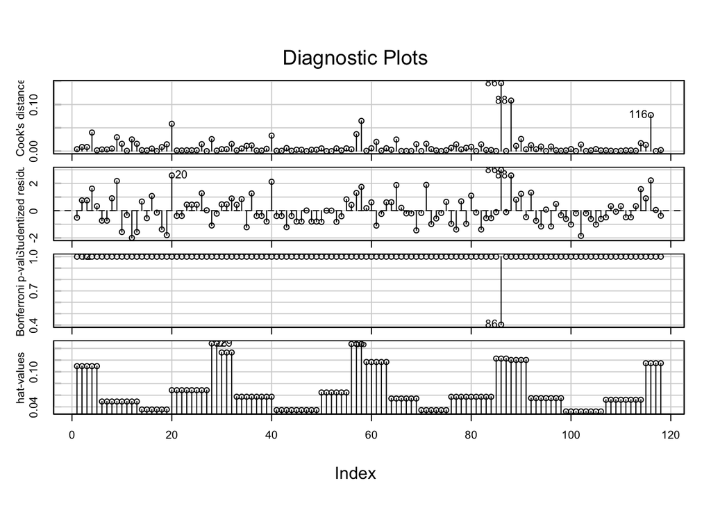

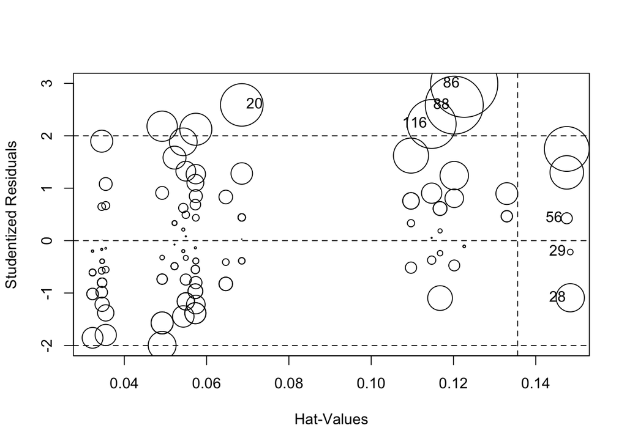

```
##        StudRes        Hat       CookD
## 20   2.5893409 0.06854839 0.058636381
## 28  -1.0900732 0.14838710 0.025836436
## 29  -0.2180011 0.14838710 0.001044139
## 56   0.4261559 0.14754098 0.003958488
## 86   2.9924850 0.12261380 0.145881093
## 88   2.5853837 0.12019231 0.108534435
## 116  2.2250583 0.11469780 0.077398288
```

```r
# Outlier Analysis :
influencePlot(reg.model, id.n=3) # A user friendly representation of the above
```

```r
data[c(20,28,29,56,86,88,116),]
```

```
##     day time logcells
## 20    1    3       10
## 28    1    4        0
## 29    1    4        2
## 56    2    4        3
## 86    3    4        9
## 88    4    0       13
## 116   4    4        7
```